# Table of Contents

- Setup and Data Loading
- Feature Engineering
- 1. Overview: Usage Split by Day Type
- 2. Temporal Patterns
  - 2.1 Intraday Usage Patterns (Hourly)
  - 2.2 Seasonal Patterns (Monthly)
- 3. POI Data Preparation
- 4. Linking Rides to POIs
- 5. Balanced Sampling — Casual vs Member
- 6. Results: Usage Patterns by POI Category
  - 6.1 Ride Share by POI Category
  - 6.2 Trip Duration by POI Category
  - 6.3 Hourly Usage by POI Category
  - 6.4 Weekday vs Weekend by POI Category
  - 6.5 Spatial View: Station POI Context Map
- 7. Methodology and Limitations
- 8. Conclusions and Recommendations
- 9. Saving Outputs

# Setup and Data Loading

↑ back to top

**Input:** `df_clean.csv` — cleaned Divvy trip data (Apr 2025 – Mar 2026).

This notebook replaces the zoning-district spatial analysis with a **POI-based analysis** that examines how casual and member riders behave differently around five categories of Points of Interest: cycling infrastructure, schools & universities, tourist attractions, business & office districts, and transport hubs.

Sections 1–2 carry over the feature engineering and temporal analysis from the parent notebook to provide context. Sections 3 onward contain the new POI pipeline.

**Additional libraries used in this notebook:**

| Library | Purpose |
| --- | --- |
| `contextily` | Basemap tiles for spatial maps |
| `geopandas` | Spatial data handling and projections |
| `scipy.spatial.cKDTree` | Fast nearest-neighbour lookup for station→POI assignment |
| `pyproj.Transformer` | CRS conversion (WGS84 → Web Mercator) |

```
Rows    : 5,614,731
Columns : 13
Columns : ['ride_id', 'rideable_type', 'started_at', 'ended_at', 'start_station_name', 'start_station_id', 'end_station_name', 'end_station_id', 'start_lat', 'start_lng', 'end_lat', 'end_lng', 'member_casual']
```

# Feature Engineering

↑ back to top

Before analysis, three derived features are added to the dataset:

1. **`trip_duration`** — ride length in minutes (capped to 1 min – 24 h to exclude outliers).
2. **`day_category`** — classifies each ride day as `weekday`, `weekend`, or `holiday` (using Illinois public holidays).
3. **`ride_date`** — date portion of `started_at` (used for normalization in time-series aggregations).

```
converting in datetime ( if not already ) started at: datetime64[ns] ended at: datetime64[ns]
```

```
From 5,614,731 to 5,462,857 rows (2.70% removed as duration outliers)
trip_duration — min: 1.0 min  max: 1440.0 min  median: 9.7 min
```

### Day category: weekday / weekend / holiday

Illinois public holidays are identified using the `holidays` library.  
A vectorized approach assigns each trip a day type without iterating row by row.

↑ back to top

```
Date range       : 2025-03-31 → 2026-03-31
Illinois holidays in range : 13
```

```
STEP 1: CREATE DAY CATEGORY COLUMN (VECTORIZED)...
```

```
Total ride distribution:
day_category
weekday    3768927
weekend    1541113
holiday     152817
Name: count, dtype: int64
```

The three categories split the dataset into distinct behavioural contexts:

- **Weekday** — likely dominated by commuters (members).
- **Weekend + Holiday** — likely dominated by leisure rides (casuals).  
  The pie chart in Section 1 will test this hypothesis at a high level.

↑ back to top

# 1. Overview: Member vs Casual Usage Split

↑ back to top

**Macro view:** what fraction of rides does each user type take on weekdays vs. weekends/holidays?  
A clear asymmetry here would be the first signal that the two groups have different use cases —  
which we will then confirm and detail in the temporal and spatial analyses below.

```
=======================================================
STEP 0 ✅ Date columns converted & 'ride_date' created
  → Total rows  : 5,462,857
  → Date range  : 2025-03-31 → 2026-03-31
  → Unique days : 366
  ⏱ Step 0: 1.693s
```

```
=======================================================
STEP 1 ✅ Dataset split into 4 segments (no copies)
  → Weekday  | Member : 2,621,964 rides
  → Weekday  | Casual : 1,146,963 rides
  → Weekend  | Member :  909,877 rides
  → Weekend  | Casual :  784,053 rides
  → Total   (check)  : 5,462,857 rides
  ⏱ Step 1: 0.381s
```

```
=======================================================
STEP 2+3 ✅ Single groupby replaces function + 4 calls
  Segment                  Tot. min   Days  Avg min/day
  ----------------------------------------------------
  Weekday  | Member      31,109,081    249    124,936.1
  Weekday  | Casual      20,515,602    249     82,392.0
  Weekend  | Member      12,153,929    117    103,879.7
  Weekend  | Casual      17,755,433    117    151,755.8
  ⏱ Step 2+3: 0.463s

=======================================================
STEP 4 ✅ Pie chart percentages computed
  → MEMBER  — Weekday: 54.6%  |  Weekend: 45.4%
  → CASUAL  — Weekday: 35.2%  |  Weekend: 64.8%
  ⏱ Step 4: 0.000s
```

```
=======================================================
STEP 5 ✅ Raw values — final sanity check
WEEKDAY MEMBER : 31109080.6 249 124936.06666666667
WEEKEND MEMBER : 12153929.41 117 103879.73854700854
WEEKDAY CASUAL : 20515602.25 249 82391.97690763052
WEEKEND CASUAL : 17755433.08 117 151755.83829059827
  → Temp column 'day_cat_simple' removed ✅
=======================================================
```

The pie charts show the weekday/weekend split for each user type.  
A 50/50 split means usage is evenly distributed. A strong skew toward one day type  
is the first evidence of a commute-driven (member) vs. leisure-driven (casual) pattern.

↑ back to top

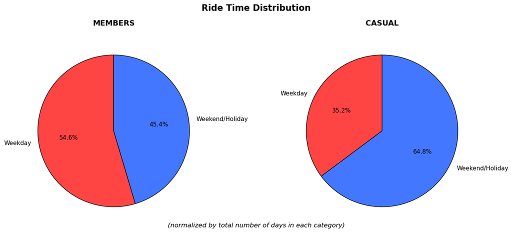

# 2. Temporal Analysis

↑ back to top

The macro split from Section 1 tells us *which days* each group prefers.  
Here we zoom in on **when during the day** and **which months** each group rides most.  
Together, these three temporal lenses paint a full picture of the usage calendar.

## 2.1 Intraday Usage Patterns (Hourly)

↑ back to top

**Zoom:** the macro view showed members use the service more on weekdays. Now we ask:  
*at which hours of the day do members and casuals differ most?*  
We expect members to show double peaks at commute times (8 am, 5–6 pm) while casuals  
should peak in the early afternoon — consistent with leisure use.

The metric is **total hours of usage per day** (normalized by the number of unique days  
in each group) — this corrects for the different number of weekday vs. weekend days in the dataset.

```
=======================================================
STEP 0 ✅ Group encoding done
  → weekday_member      : 2,621,964 rides |  249 days
  → weekday_casual      : 1,146,963 rides |  249 days
  → weekend_member      :  909,877 rides |  117 days (weekend + holiday)
  → weekend_casual      :  784,053 rides |  117 days (weekend + holiday)
  ⏱ Step 0: 0.950s
```

```
=======================================================
STEP 1 ✅ Numba: single pass completed
  → Output shape: (4, 24)  (4 groups × 24 hours)
  → Total minutes processed: 81,534,045
  ⏱ Step 1: 0.499s

=======================================================
STEP 2 ✅ Normalization done
  → weekday_member      : peak hour 17:00 → 265.411 h/day
  → weekday_casual      : peak hour 17:00 → 142.987 h/day
  → weekend_member      : peak hour 16:00 → 142.535 h/day
  → weekend_casual      : peak hour 15:00 → 235.879 h/day
  ⏱ Step 2: 0.001s

=======================================================
STEP 3 ✅ Colors and titles configured
  → Weekday: #ff4444 (red) | Weekend+Holiday: #4477ff (blue)
```

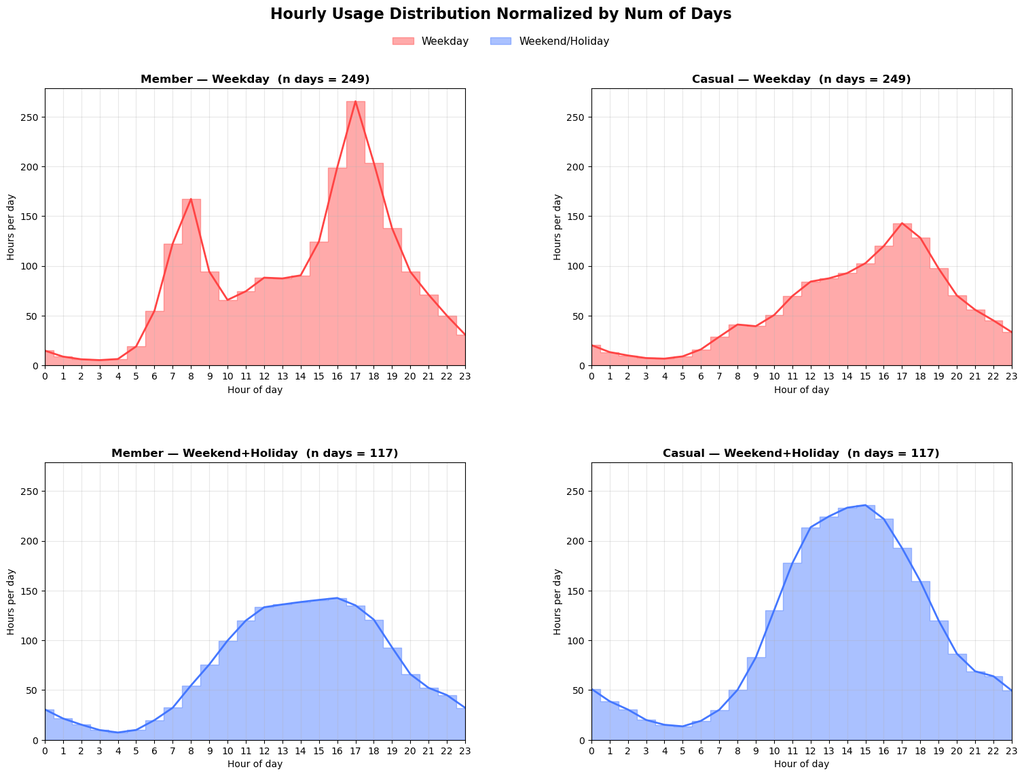

```
=======================================================
STEP 5 ✅ Export done + temporary columns removed
  → ../reports/figures/hourly_usage_weekday_vs_weekend.png
  → ../data/processed/hourly_usage.csv
  → Column 'group_id' removed from df_clean ✅

  ⏱ TEMPO TOTALE: 2.411s
=======================================================
```